# Demo: Control-flow

NIHES BST02

Nicole Erler, Department of Biostatistics, Erasmus Medical Center

14 February 2020

## `ifelse()` vs `if() ... else ...`

Let’s see what happens when we use the `ifelse()` example from the slides with `if() ... else ...`

```
 [1] ">0" ">0" "<0" "<0" "<0" "<0" ">0" "<0" ">0" ">0"
```

```
[1] ">0"
```

The problem here is that `if()` expects an expression that either returns `TRUE` or `FALSE`, but we gave it a vector:

```
 [1] FALSE FALSE  TRUE  TRUE  TRUE  TRUE FALSE  TRUE FALSE FALSE
```

In this case, only the first element of this vector is used.

On the other hand, the `if () ... else ...` example from the slides works in both cases:

```
[1] 0.172405
```

```
[1] 0.172405
```

But for other cases it may not do what we expect it to do:

```
$a
[1] 5

$b
[1] -1.279543153 -0.005840453  0.499322599 -1.561777224  0.146231265  0.921295255  1.928795859

$c
[1] -1.4414449 -0.5941584  0.8500933  0.2995579
```

```
[[1]]
[1] 5
```

Here, the “test” `length(x) > 5` results in `FALSE`, but because `ifelse()` expects a vector of “tests” (and only receives one “test”), it will only return the first element of `x`.

But `if() ... else ...` also does not work per element:

```
$a
[1] 5

$b
[1] -1.279543153 -0.005840453  0.499322599 -1.561777224  0.146231265  0.921295255  1.928795859

$c
[1] -1.4414449 -0.5941584  0.8500933  0.2995579
```

## `for()`-loop

We could solve the above issue using a `for()`-loop. This allows us to look at each element of `x` separately. Here, the function `seq_along()` comes in handy:

```
[1] 1 2 3
```

It produces a sequence with the same length as `x` has elements. Because we are using a loop, we need to add the `print()` function to see the printed output.

```
[1] 5
[1] 0.09264059
[1] -1.4414449 -0.5941584  0.8500933  0.2995579
```

We could also “collect” the output in a new object:

```
[[1]]
[1] 5

[[2]]
[1] 0.09264059

[[3]]
[1] -1.4414449 -0.5941584  0.8500933  0.2995579
```

## An example with `while()`

`while()` requires a `condition` that at some point is `FALSE` for the loop to stop.

The following would run forever (stop it by pressing “Esc” when in the Console):

This one here could also take very long. Instead of printing the output we save it in a vector that we can plot afterwards.

```
[1] 451
```

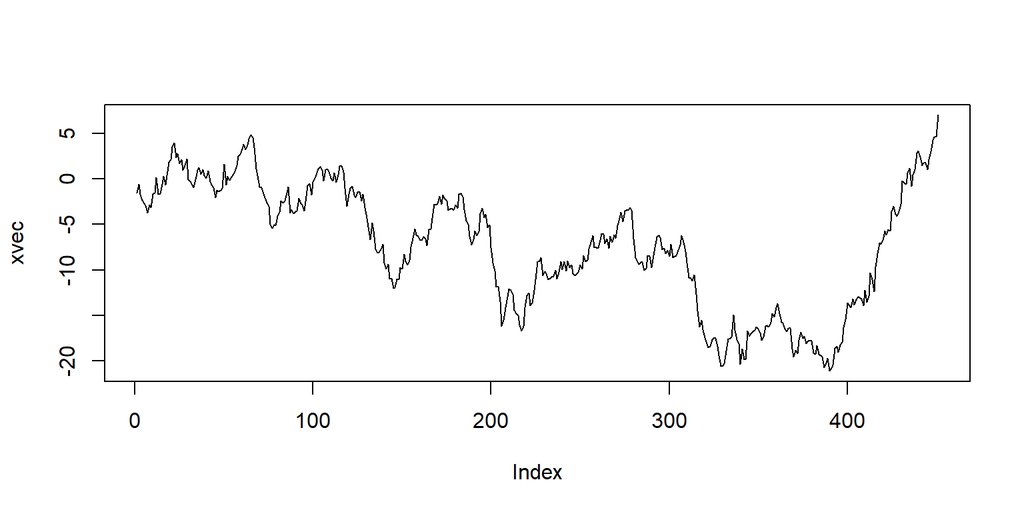

We could extend the syntax from above by adding a counter

```
[1] 0.8227053 1.0995877 1.1695185 3.0570704 5.0605848
```

Now we will get a maximum of 25 iterations. The loop stops as soon as `x` is larger than or equal to 5, or if 25 iterations are reached.